# HW1

Michele Amoroso 1760027 e Manuel Balzan 1936818

11/16/2020

–PART A–

For this exercise, we are trying to verify that the randomized max-cut algorithm returns a cut that is at least of size OPT/2, where OPT is the size of the maximum cut.

```r
library(igraph)
library(ggraph)
library(sdpt3r)
library(reshape2)
library(MASS)
```

The following algorithm uses a built-in function called maxcut, which should return a good approximation of the maximum cut

```r
#get an approximation of max cut using the function maxcut()
get_approx_maxcut = function(G){
  G_mat_adj = as_adjacency_matrix(G)
  G_mat = as.matrix(G_mat_adj)
  return(-maxcut(G_mat)$pobj)
}
```

Here is an implementation of an algorithm that finds the optimal solution to the max-cut problem

```r
#given a set of vertices and the edges of the graph, returns the cardinality of the cut set
cut_len = function(v_set, edges){
  count = 0
  for(i in 1:nrow(edges)){
    if(edges[i, 1] %in% v_set){
      if(!(edges[i, 2] %in% v_set)){
        count = count + 1
      }
    }else{
      if((edges[i, 2] %in% v_set)){
        count = count + 1
      }
    }
  }
  return(count)
}
```

```r
#given a graph return the real maxcut
get_real_maxcut = function(G){
  edges = as_edgelist(G)
  vertices = V(G)
  max_cut = 0
  cut_content = c()
  for(i in 1:length(vertices)){
    comb = t(combn(vertices, i))
    for(j in 1:nrow(comb)){
      cut = cut_len(comb[j, ], edges)
      if(cut > max_cut){
        max_cut = cut
        cut_content = comb[j, ]
      }
    }
  }
  return(list(max_cut, cut_content))
}
```

This is the randomized version of the algorithm, which iterates over each vertices and includes them in the cut with 50% probability. The built-in function ‘sample’ is used as our RNG. We ran the experiment 100 times and defined our max-cut estimate as the average size of the 100 cuts.

```r
random_maxcut = function(G){
  vertices = V(G)
  edges = as_edgelist(G)
  v_set_random = c()
  for(i in 1:length(vertices)){
    if(sample(1:2, 1) == 1){
      v_set_random = c(v_set_random, vertices[i])
    }
  }
  return(cut_len(v_set_random, edges))
}
```

```r
get_random_cut = function(G){
  total = 0
  num = 0
  for(i in 1:100){
    total = total + random_maxcut(G)
    num = num + 1
  }
  return(total/num)
}
```

The max-cut algorithm is np-hard. This means that it hasn’t been solved in polynomial time or less. We expect then that our optimal algorithm will perform (in terms of time) much worse than the other 2 implementations.

Let’s verify that.

```r
#create a random undirected graph which has, for each pairs of vertex, 0.5 probability to have an edge
G1 = sample_gnm(7, 7, directed = FALSE) # 7 edges graph
G2 = sample_gnm(20, 20, directed = FALSE) # 20 edges graph
```

```r
# Testing real maxcut
start_time = Sys.time()
list_cut = get_real_maxcut(G1)
real_max_cut = list_cut[1]
cut_content = list_cut[2]
end_time = Sys.time()
end_time - start_time
```

```
## Time difference of 0.0472362 secs
```

```r
start_time = Sys.time()
list_cut = get_real_maxcut(G2)
real_max_cut = list_cut[1]
cut_content = list_cut[2]
end_time = Sys.time()
end_time - start_time
```

```
## Time difference of 2.039285 mins
```

```r
#Testing approx maxcut
start_time = Sys.time()
approx_max_cut = get_approx_maxcut(G1)
end_time = Sys.time()
end_time - start_time
```

```
## Time difference of 0.6855664 secs
```

```r
start_time = Sys.time()
approx_max_cut = get_approx_maxcut(G2)
end_time = Sys.time()
end_time - start_time
```

```
## Time difference of 1.498249 secs
```

```r
#Testing randomized maxcut
start_time = Sys.time()
real_max_cut = get_random_cut(G1)
end_time = Sys.time()
end_time - start_time
```

```
## Time difference of 0.03611732 secs
```

```r
start_time = Sys.time()
real_max_cut = get_random_cut(G2)
end_time = Sys.time()
end_time - start_time
```

```
## Time difference of 0.07761145 secs
```

As we can see, calculating the optimal cut takes significantly more time than the randomized one. Notice that for small graphs (e.g. 7 nodes) the built-in function maxcut (approximated max-cut) seems to be slower than the optimal algorithm, but again as we increase the graph size the approximated version becomes faster.

Now let’s compare the size of the cut returned by each implementation. To do so, we create 14 random graphs with different number of vertices

```r
#create a matrix: rows = graphs, cols = implementations
graph_list = c()
mat = matrix(nrow = 14, ncol = 4)
for(i in 4:17){
  G = sample_gnm(i, i, directed = FALSE)
  approx_max_cut = get_approx_maxcut(G)
  random_cut = get_random_cut(G)
  real_max_cut_list = get_real_maxcut(G)
  real_max_cut = real_max_cut_list[[1]]
  if((i %% 4) == 0){
    cut_content = real_max_cut_list[[2]]
    graph_list = append(graph_list, list(G, cut_content))
  }
  mat[i-3, 1] = i
  mat[i-3, 2] = round(approx_max_cut, digits = 2)
  mat[i-3, 3] = real_max_cut
  mat[i-3, 4] = random_cut
}
```

```r
#convert the matrix to a table
df = as.data.frame(mat)
colnames(df) <- c("vertices", "approximate max cut","real max cut","randomized max cut")
df
```

```
##    vertices approximate max cut real max cut randomized max cut
## 1         4                3.25            3               1.92
## 2         5                4.00            4               2.69
## 3         6                5.25            5               3.07
## 4         7                6.25            6               3.50
## 5         8                8.00            8               4.05
## 6         9                8.25            8               4.37
## 7        10                9.19            9               5.02
## 8        11               10.00           10               5.34
## 9        12               10.17           10               6.01
## 10       13               11.06           11               6.63
## 11       14               14.00           14               7.04
## 12       15               13.53           13               7.63
## 13       16               15.00           15               7.94
## 14       17               16.77           16               8.67
```

It is clear that, for each of our test graph sizes, the randomized max-cut algorithm return a cut whose size is at least half of the optimal cut.

To better understand what a max-cut looks like, here’s a graphical representation of some of the graph generated in the previous part. The red and blue vertices represent the subsets of the cut partition.

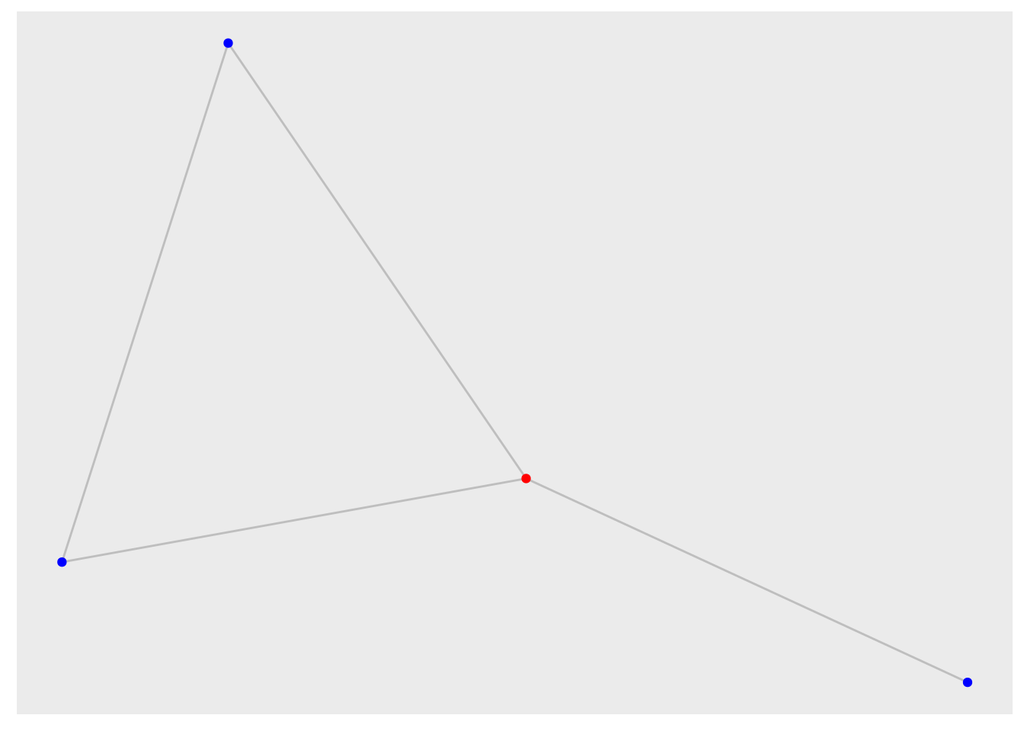

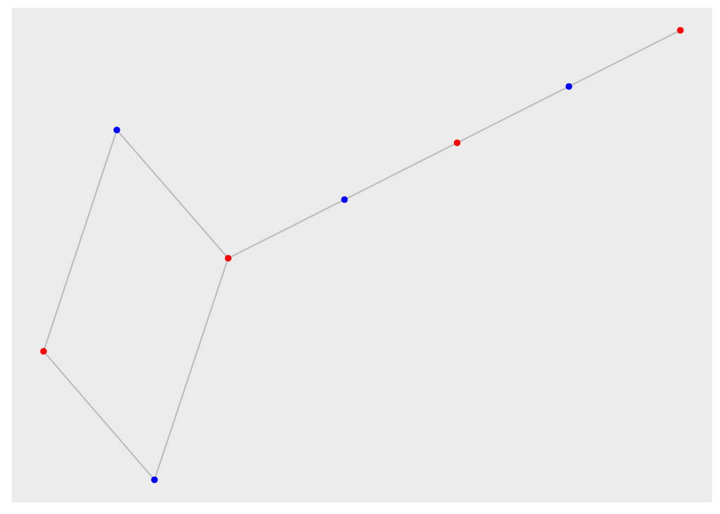

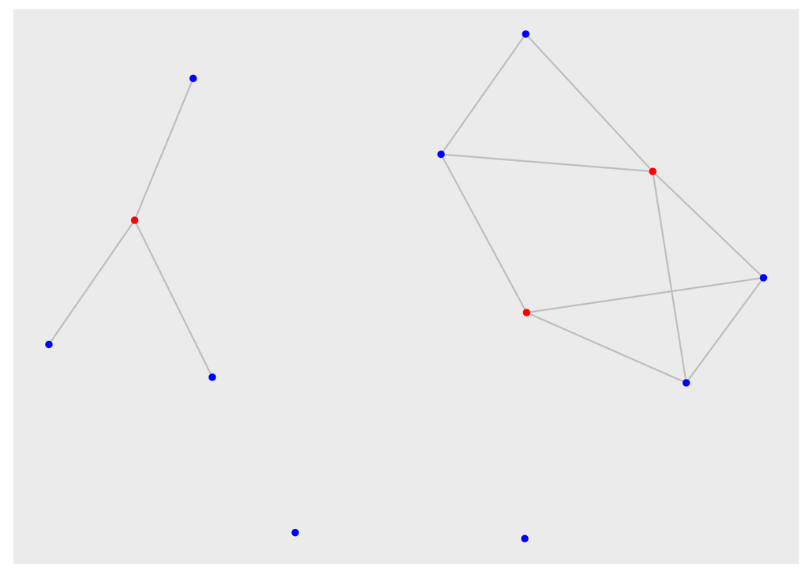

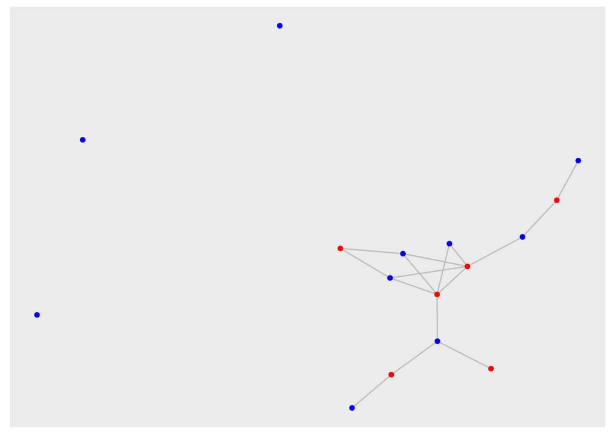

```r
for (i in seq(1, length(graph_list), by=2)) {
  graph = graph_list[[i]]
  cut = graph_list[[i+1]]
  for(j in 1:length(V(graph))){
    if(V(graph)[j] %in% cut){
      V(graph)[j]$color = "red"
    }else{
      V(graph)[j]$color = "blue"
    }
  }
  print(ggraph(graph, layout = "kk") +
    geom_edge_link(edge_colour = "grey") +
    geom_node_point(colour = V(graph)$color))
}
```

= PART B =

For this exercise we are simulating the so called preferential attachment process and analyzing the resulting distribution.

We first define a function that, given a 2x4 matrix (representing a directed cycle on 4 vertices) adds n vertices (and links) one at a time, connecting them to the existing graph in two possible ways: 1. link the new vertex to a random vertex of the existing graph 2. link the new vertex to a vertex of the existing graph chosen at random between those who already have an inlink

Each of the possible ways have a 50% percent probability of being selected.

```r
add_links = function(edges, n){
  for(i in 5:n){
    if(sample(1:2, 1) == 1){
      v_random = sample(1:(i-1), 1)
      edges[i, 1] = i
      edges[i, 2] = v_random
    }else{
      row_random = sample(1:(i-1), 1)
      e_random = edges[row_random, 2]
      edges[i, 1] = i
      edges[i, 2] = e_random
    }
  }
  G = graph_from_edgelist(edges, directed = TRUE)
  return(G)
}
```

We are now creating a list of 5 elements which will contain 5 graphs. We are also setting the size of each graph at 1 Mln nodes

```r
g_list = vector("list", 5)
n = 1000000
```

Here we are creating the starting graph (directed cycle on 4 vertices). Then we add the remaining vertices and store each graph in the list

```r
edges = matrix(nrow = n, ncol = 2)
edges[1:4, 1:2] <- c(1,2,3,4,2,3,4,1)
for(i in 1:5){
  G = add_links(edges, n)
  g_list[[i]] = G
}
```

We are now plotting, for each graph, their empirical degree distribution which show the number of vertices of each degree on a log-log plot. We are also plotting, on the same figure a power law distribution and a Poisson distribution fitted on our graphs.

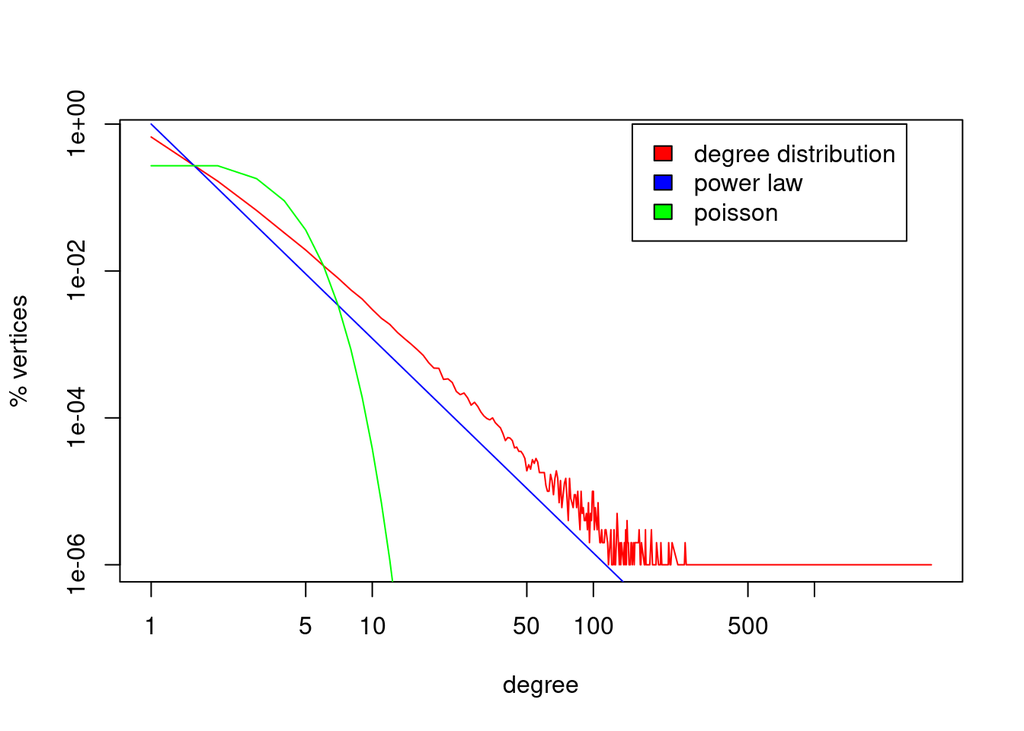

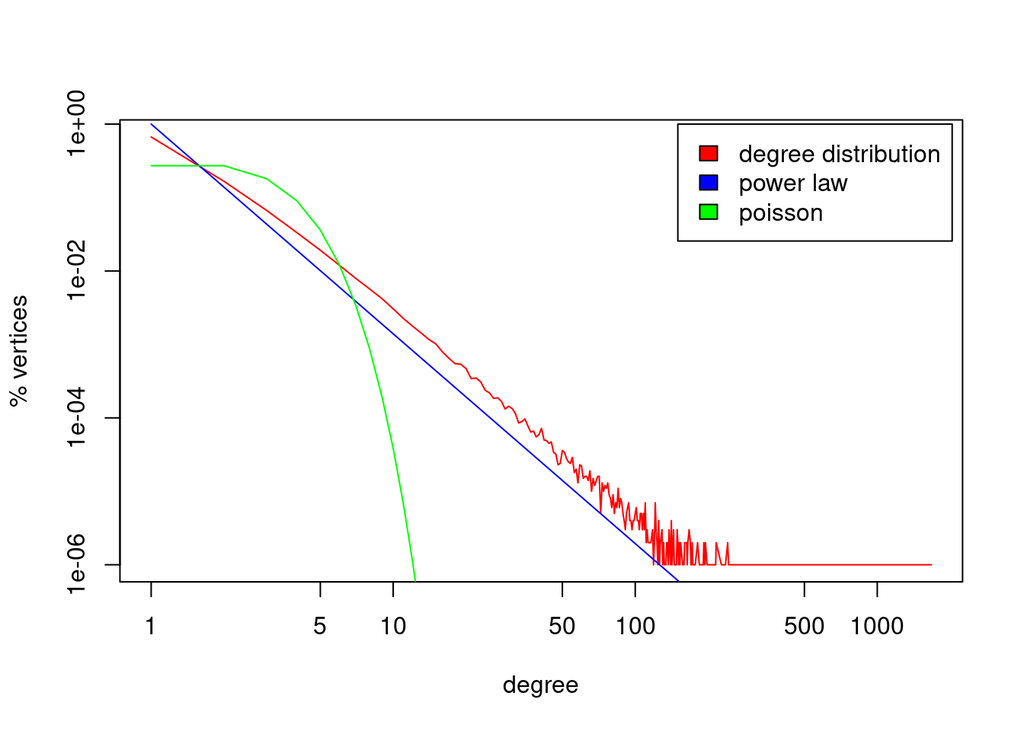

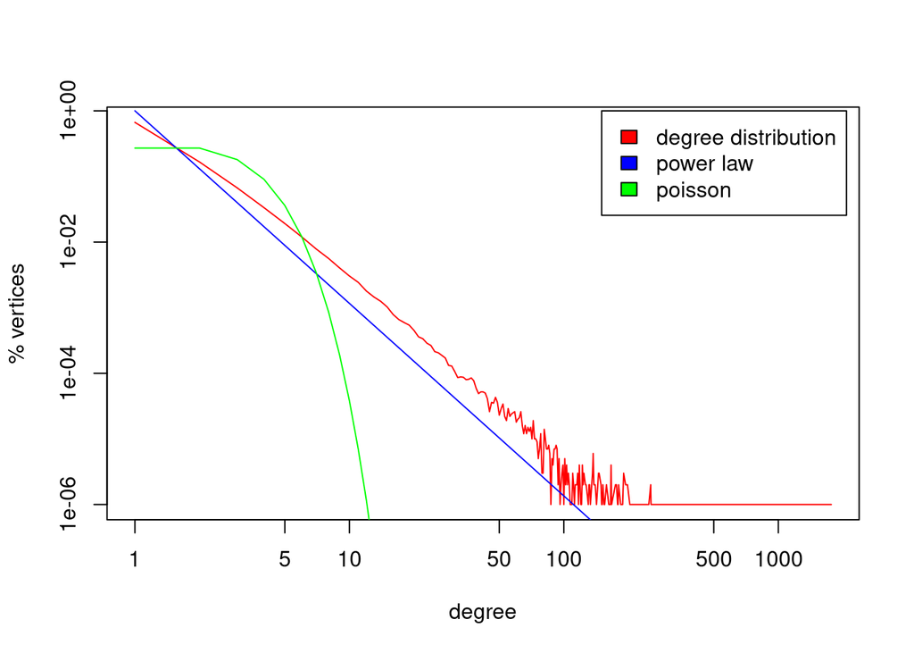

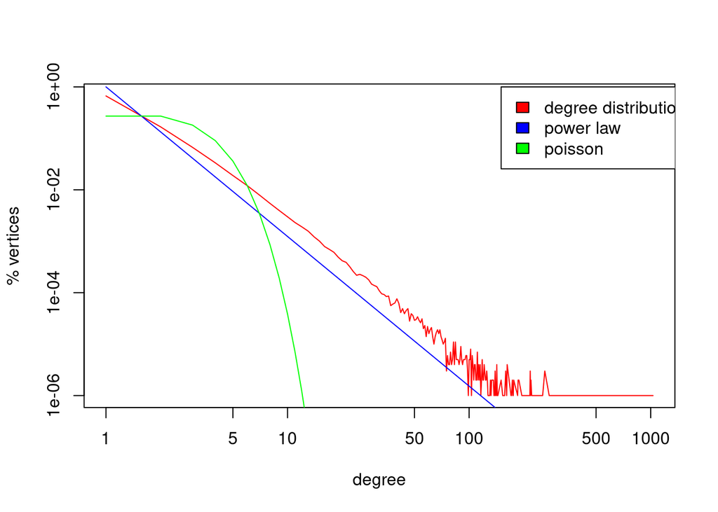

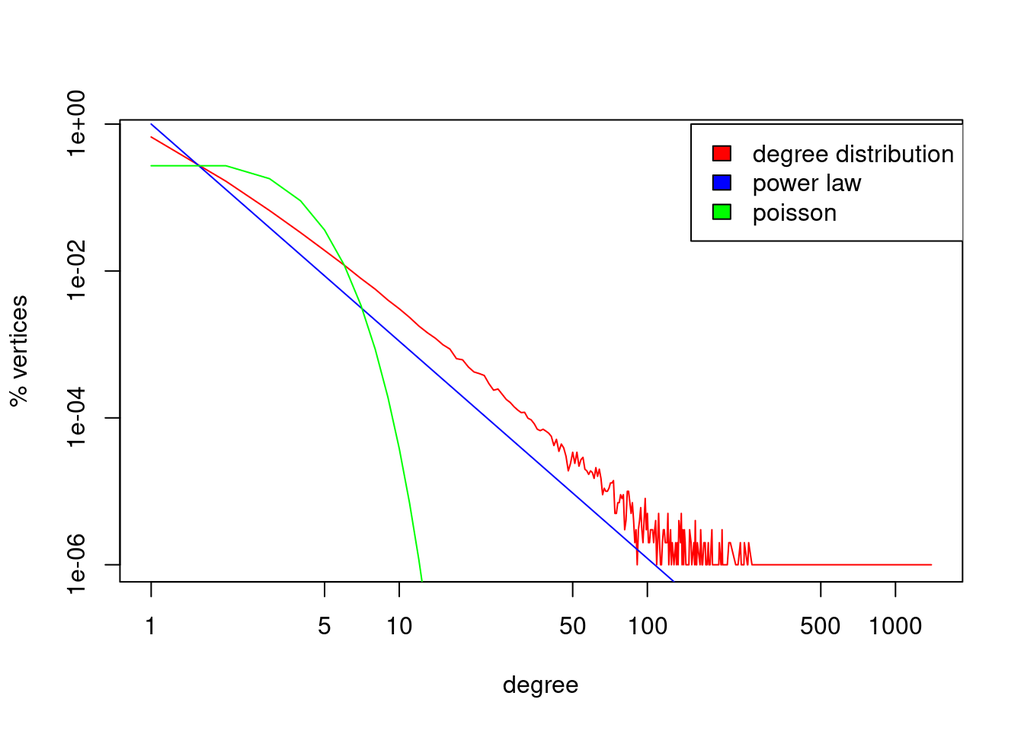

```r
for(i in 1:length(g_list)){
  G = g_list[[i]]
  degree = degree(G, v = V(G), mode = c("all"))
  dd = degree_distribution(G, cumulative = FALSE)
  dd = dd[-1]#*n
  idx = which(dd != 0)
  dd = dd[idx]

  fit1 = fit_power_law(degree)
  alpha = fit1$alpha
  m = length(idx)
  x = c(1:m)

  plot(idx, dd, log = "xy", type="l", col = "red", xlab = "degree", ylab = "% vertices")
  lines(x, x^(-fit1$alpha), col = "blue")

  fit2 = fitdistr(degree, "Poisson")
  m = 1000000
  x = c(1:m)

  lines(x, dpois(x,lambda=fit2$estimate), col = "green")

  legend(150, 1, legend = c("degree distribution", "power law", "poisson"),
       col = c("red", "blue", "green"), fill = c("red", "blue", "green"))

}
```

As we can see from the plots above, the degree distribution appears to follow a power law. We also get similar results for each graph.

Now we are plotting the complimentary cumulative degree distribution, that is the number of vertices with degree at least k for every value of k (on a log-log plot).

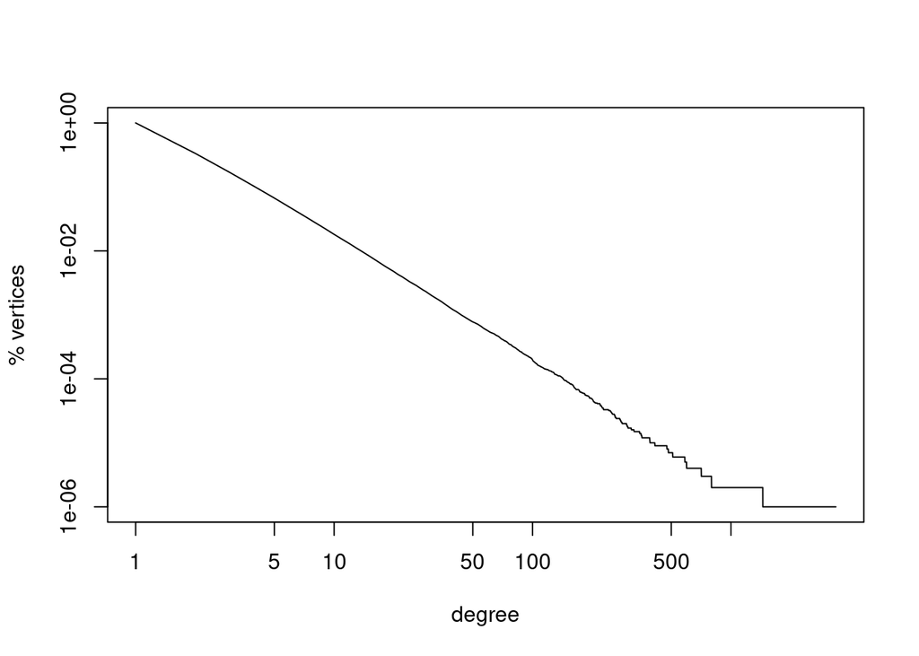

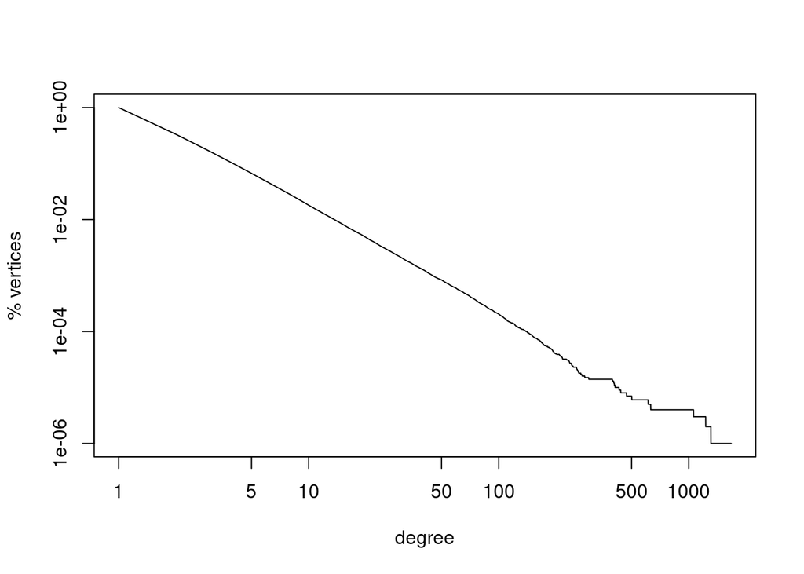

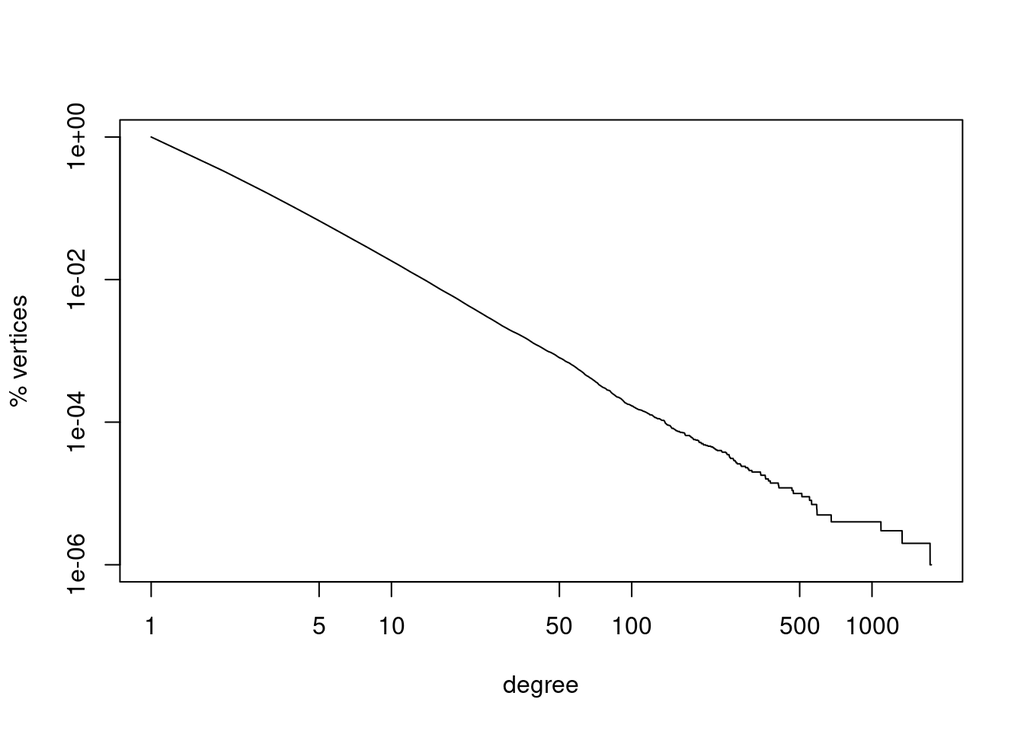

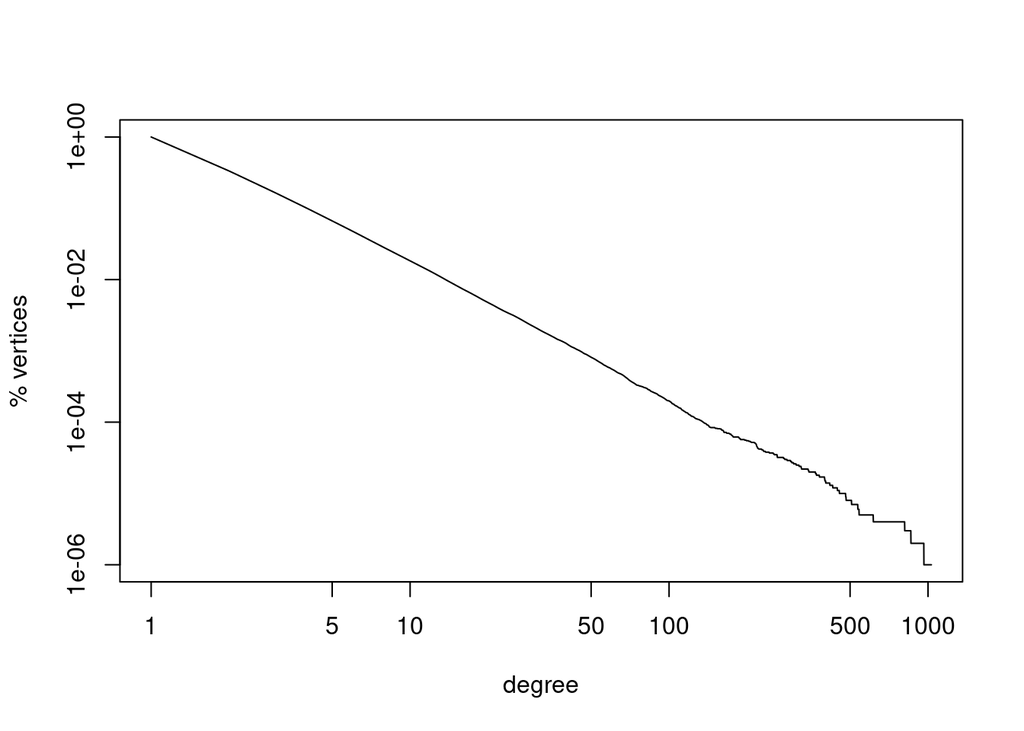

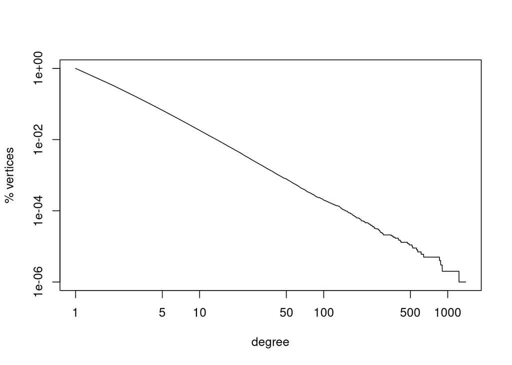

```r
for(i in 1:length(g_list)){
  G = g_list[[i]]

  degree = degree(G, v = V(G), mode = c("all"))
  dd = degree_distribution(G, cumulative = TRUE)
  dd = dd[-1]#*n
  idx = 1:length(dd)

  plot(idx, dd, log = "xy", type="l", xlab = "degree", ylab = "% vertices")
}
```

Below is plotted a graph with 1000000 vertices.

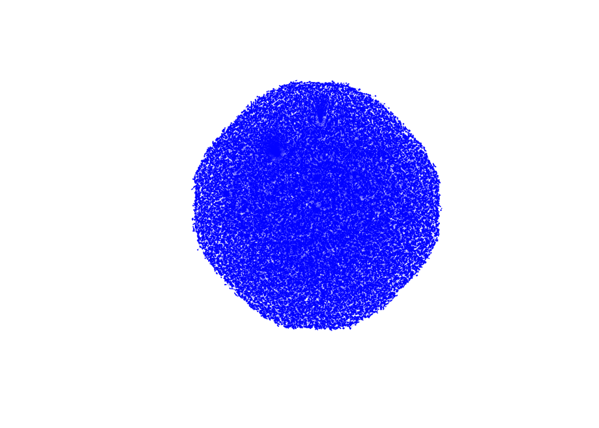

```r
G = g_list[[1]]

plot(simplify(G), vertex.size= 0.01, edge.arrow.size=0.001, vertex.label.cex = 0.75,vertex.label.color = "black", vertex.frame.color = adjustcolor("black", alpha.f = 0), vertex.color = adjustcolor("black", alpha.f = 0), edge.color=adjustcolor("blue", alpha.f = 0.15), display.isolates=FALSE, vertex.label=ifelse(page_rank(G)$vector > 0.1 , "", NA))
```

To better visualize the structure of the graph, we decided to plot one with fewer vertices (10000). As we can see there are some hubs and the degree distribution follows a power law.

```r
n = 10000
edges = matrix(nrow = n, ncol = 2)
edges[1:4, 1:2] <- c(1,2,3,4,2,3,4,1)
G = add_links(edges, n)
degree = degree(G, v = V(G), mode = c("all"))
```

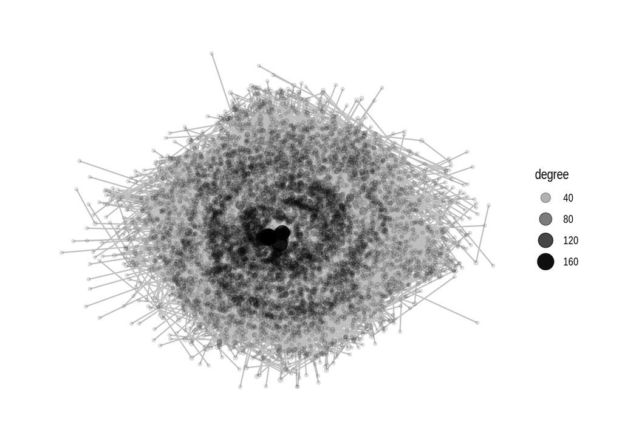

```r
ggraph(G, layout = "kk") +
  geom_edge_link(edge_colour = "grey") +
  geom_node_point(aes(size = degree, alpha = degree), colour = "black")+
  theme_graph()
```